# 大数据审计

专题1：会计数据类型

黄敬昌

2021-10-25

# 会计数据类型 Accounting Data Types

McCarthy（1979，1982）提出了将Chen（1976）框架应用于会计的会计制度设计理论。McCarthy理论认为，会计交易是一个经济实体与其他方的经济活动的核算。这些核算记录了**数字、时间、分类和描述性信息**。分类是由公司的会计科目表决定的，用于划分公司经济活动的类型。会计核算是以货币为单位的，并且需要以一定方式来评价经济事件。交易时间的记录可以确保在正确的会计期间记录经济事件。描述性信息是在日记帐分录的附注中输入的。

但社交网络和媒体提供了大量以**文本形式存储的信息**，如果没有计量这些信息，就会大大增加审计失败的风险。 对不同类型的信息的处理和解释是不同的，信息技术、统计方法和软件决定了数据类型，以及数据的处理和存储。 R语言擅长管理数据，这种特殊的优势使R作为一种审计语言胜过其他语言。比如，在使用R时，审计师不必担心客户的某些数据没办法读取；对于常见的数据结构和格式，无论是实时流、基于网络的、基于云的，还是基于客户的定制系统，都可以使用R代码进行分析，最终形成**审计数据分析报告**。

## 数值型与分类型

结构化数据有两种基本类型：数值型和分类型。数值型数据有两种形式：连续的（如金额或持续时间）；离散的（如事件发生的次数）。分类型数据是采用一组固定的值，例如电视屏幕的类型（等离子、LCD、LED等）；或省的名称（广东省、湖南省等）。二元数据是分类数据的一个重要特例，它只有两个值，如0/1、是/否或真/假。另一种有用的分类数据类型是对类别进行排序的顺序数据，比如债券评级(AAA，AA+，AA，AA-或A+)。

我们为什么要对数据类型进行分类呢？因为（1）对于数据分析和预测建模来说，数据类型对于帮助确定视觉显示、数据分析或统计模型的类型非常重要；（2）数据科学软件（如R和Python）使用这些数据类型来提高计算性能；（3）变量的数据类型决定了软件将如何处理该变量的计算。

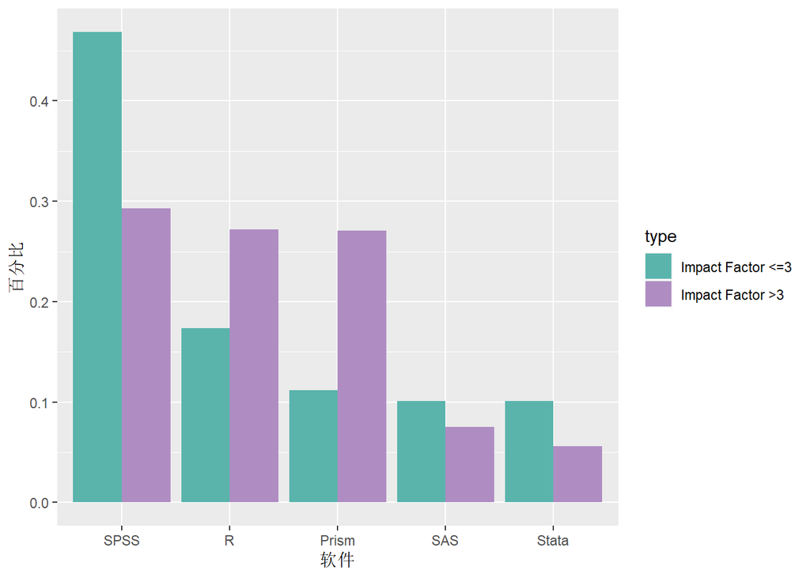

统计软件份额

```r
library(ggplot2)
data_m <- read.csv("https://toscode.gitee.com/JCHACC/BDA/raw/master/sta_sftw.csv")
data_m$name <- factor(data_m$name,levels=c("SPSS","R","Prism","SAS","Stata"))
p <- ggplot(data_m, aes(x=name , y=percentage))
p + geom_bar(stat="identity", position="dodge", aes(fill=type)) + scale_fill_manual(values = c( "#5ab4ac", "#af8dc3")) + labs(x="软件", y="百分比")
```

```r
# 统计描述，了解整个数据的情况（数据来源）
library(tidyverse)
library(plotluck)
library(broom)
sox_stats <- read.csv("https://toscode.gitee.com/JCHACC/BDA/raw/master/BDA_data_types.csv")
summary(sox_stats)
```

```
##     ticker               date          card                disc
##  Length:1514        Min.   :2005   Length:1514        Min.   :0.0000
##  Class :character   1st Qu.:2007   Class :character   1st Qu.:0.0000
##  Mode  :character   Median :2010   Mode  :character   Median :0.0000
##                     Mean   :2010                      Mean   :0.1739
##                     3rd Qu.:2013                      3rd Qu.:0.0000
##                     Max.   :2016                      Max.   :1.0000
##                     NA's   :2                         NA's   :2
##       hack             insd             phys             port
##  Min.   :0.0000   Min.   :0.0000   Min.   :0.0000   Min.   :0.0000
##  1st Qu.:0.0000   1st Qu.:0.0000   1st Qu.:0.0000   1st Qu.:0.0000
##  Median :0.0000   Median :0.0000   Median :0.0000   Median :0.0000
##  Mean   :0.2467   Mean   :0.1382   Mean   :0.0463   Mean   :0.2837
##  3rd Qu.:0.0000   3rd Qu.:0.0000   3rd Qu.:0.0000   3rd Qu.:1.0000
##  Max.   :1.0000   Max.   :1.0000   Max.   :1.0000   Max.   :1.0000
##  NA's   :2        NA's   :2        NA's   :2        NA's   :2
##       stat              unkn         effective_303     mat_weak_303
##  Min.   :0.00000   Min.   :0.00000   Min.   :0.0000   Min.   :0.00000
##  1st Qu.:0.00000   1st Qu.:0.00000   1st Qu.:1.0000   1st Qu.:0.00000
##  Median :0.00000   Median :0.00000   Median :1.0000   Median :0.00000
##  Mean   :0.03704   Mean   :0.03968   Mean   :0.9616   Mean   :0.03241
##  3rd Qu.:0.00000   3rd Qu.:0.00000   3rd Qu.:1.0000   3rd Qu.:0.00000
##  Max.   :1.00000   Max.   :1.00000   Max.   :1.0000   Max.   :1.00000
##  NA's   :2         NA's   :2         NA's   :2        NA's   :2
##   sig_def_303         auto_1       auditor_agrees_303 effective_404
##  Min.   :0.0000   Min.   :0.0000   Min.   :0.00000    Min.   :0.0000
##  1st Qu.:0.0000   1st Qu.:0.0000   1st Qu.:0.00000    1st Qu.:0.0000
##  Median :0.0000   Median :0.0000   Median :0.00000    Median :0.0000
##  Mean   :0.1157   Mean   :0.2037   Mean   :0.08003    Mean   :0.3935
##  3rd Qu.:0.0000   3rd Qu.:0.0000   3rd Qu.:0.00000    3rd Qu.:1.0000
##  Max.   :1.0000   Max.   :1.0000   Max.   :1.00000    Max.   :1.0000
##  NA's   :2        NA's   :2        NA's   :2          NA's   :2
##    audit_fee         non_audit_fee         tax_fees
##  Min.   :   100000   Min.   :       0   Min.   :       0
##  1st Qu.:  3785984   1st Qu.:  477686   1st Qu.:   93140
##  Median :  7956000   Median : 1068000   Median :  370000
##  Mean   : 15321536   Mean   : 3679039   Mean   : 1451705
##  3rd Qu.: 17800000   3rd Qu.: 3400000   3rd Qu.: 1311000
##  Max.   :112200000   Max.   :41100000   Max.   :20800000
##  NA's   :2           NA's   :2          NA's   :2
```

## 连续数据

连续数据是相邻两个数值可作无限分割（即可取无限个数值）的数据。很多主要财务指标是连续变量，我们可以用plotluck包来研究连续数据的密度函数。

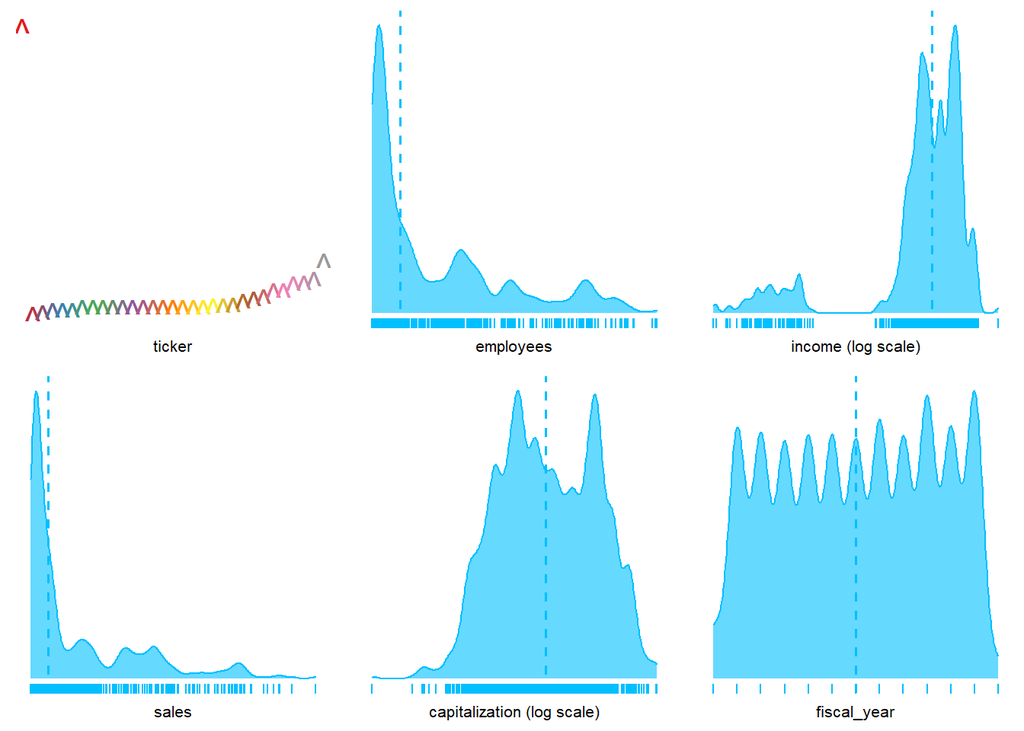

使用plotluck包查看变量密度函数

```r
library(tidyverse)
library(plotluck)
library(broom)
industry_stats <- read.csv("https://toscode.gitee.com/JCHACC/BDA/raw/master/BDA_dataset.csv")
plotluck(industry_stats, .~1)     # 用所有变量.对~1，截距作图
```

## 离散数据

离散数据是指其数值只能用自然数或整数单位计算的数据。在以下例子中，我们使用ggplot来生成离散值的直方图。这里的bins=20，表示最后结果处理柱状图一共有20个柱，这些柱不是越多越好，如果很多的话，相当于曲线图

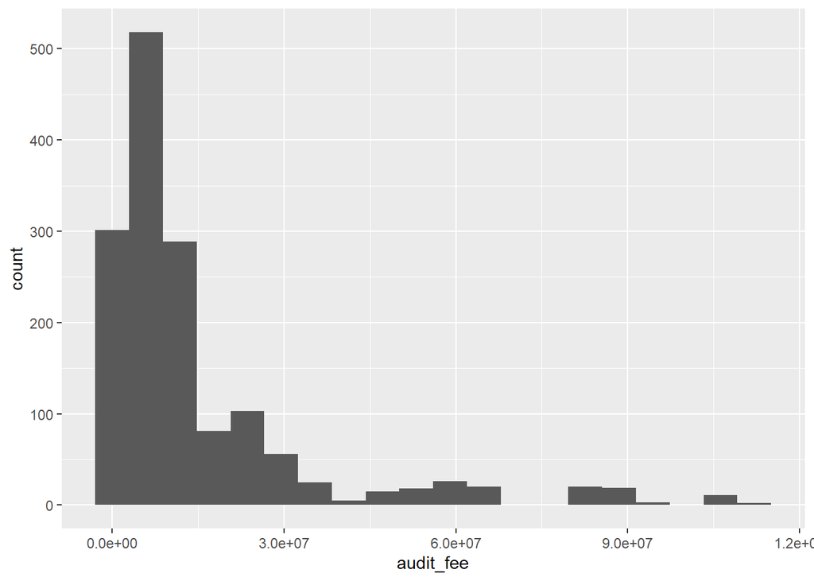

```r
library(ggplot2)
sox_stats <-   read.csv("https://toscode.gitee.com/JCHACC/BDA/raw/master/BDA_data_types.csv")
sox_stats[,c("audit_fee","non_audit_fee","tax_fees")] %>%
ggplot(aes(x=audit_fee)) + geom_histogram(bins=20)
```

## 分类数据

分类数据是按照现象的某种属性对其进行分类或分组而得到的反映事物类型的数据。分类数据只能采取一组特定的值，代表一组类别。公司的会计科目表把各种经济事件变成一个分类数据（应收账款、应付账款等），这些事件是会计系统中日记帐分录的基础。在下面这个例子中，如果我们对审计费用随时间变化的情况感兴趣，审计费用可以按照公司来分类。

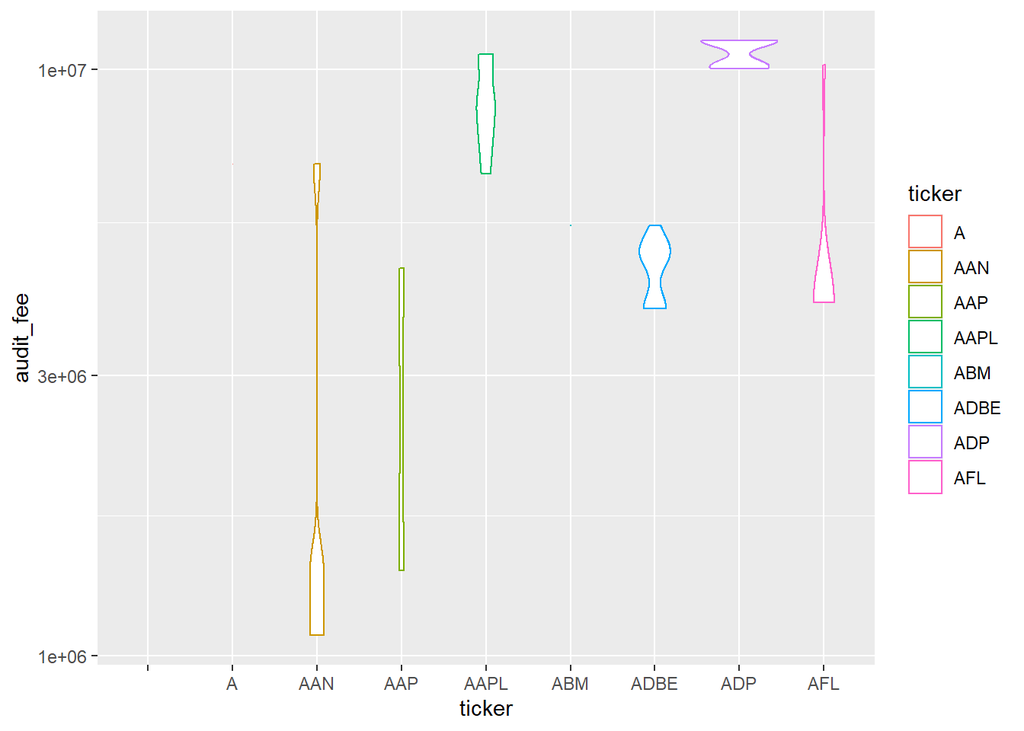

```r
# 按照公司来分类，限定ticker<'AI'，以小提琴图的方式，查看审计费用随时间变化的情况
sox_stats <- sox_stats[,c("ticker","audit_fee","non_audit_fee","tax_fees")]
sox_stats[which(as.character(sox_stats$ticker)<'AI'), ] %>%   # ticker<'AI'
ggplot(aes(x=ticker, y= audit_fee, col=ticker)) + geom_violin() + scale_y_continuous(trans = "log10")
```

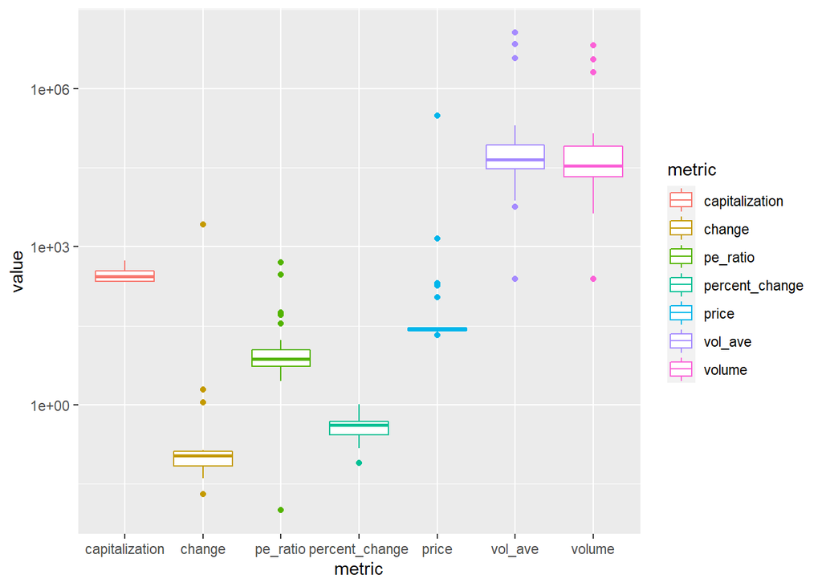

```r
# 按照每一个分类（每一个字段）每一个字段取值范围的箱型图
library(tidyverse)
library(plotluck)
library(broom)
bank_fin <- read.csv("https://toscode.gitee.com/JCHACC/BDA/raw/master/BDA_yahoo_fin.csv")
bank_fin$change <- as.numeric(bank_fin$change)
bank_fin$capitalization <- as.numeric(bank_fin$capitalization )
bank_fin <- gather(bank_fin, key="metric", value = value, price, change, percent_change, volume, vol_ave, capitalization, pe_ratio)
bank_fin %>%
  ggplot(aes(x=metric, y=value, col=metric)) + geom_boxplot() + scale_y_continuous(trans = "log10")
```

## 二元数据

二元数据表示只有两个类别的**分类数据**。这些是数据提供是/否或真/假这样的答案。比如，审计意见对财务报表是否公允列报？通常我们不仅仅是对结果感兴趣，还对为什么特定的环境、政策措施或参数设置会导致这个结果感兴趣。在下图中，我们感兴趣的是信用卡欺诈是否受到审计费用的影响。我们通过观察二元变量在0或1值下其他变量的变化来分析该二元变量。

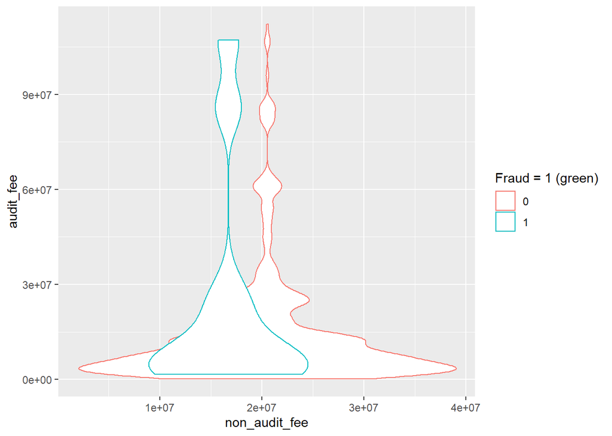

```r
# 小提琴图 ; 平均来说，不欺诈公司比欺诈公司的非审计费用要多（右）；宽度表示频率，
library(tidyverse)
library(plotluck)
library(broom)
sox_stats <- read.csv("https://toscode.gitee.com/JCHACC/BDA/raw/master/BDA_data_types.csv")
ggplot(sox_stats, aes(x=non_audit_fee, y=audit_fee, col=card)) + geom_violin() + labs(col = "Fraud = 1 (green)")
```

同样，我们可以研究审计费用对SOX报告的所有二元变量（内部控制有效性）的影响。

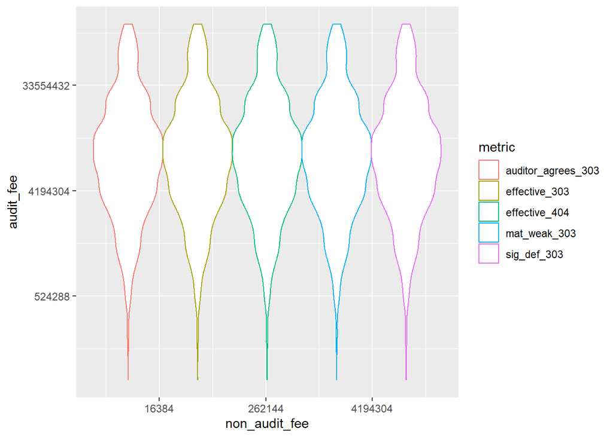

```r
library(tidyverse)
library(plotluck)
library(broom)
sox_stats <-
  read.csv("https://toscode.gitee.com/JCHACC/BDA/raw/master/BDA_data_types.csv")
sox_stats$card <- as.integer(sox_stats$card)
sox_stats1 <- gather(sox_stats, key="metric", value = value, effective_303, mat_weak_303, sig_def_303, effective_404, auditor_agrees_303)
ggplot(sox_stats1, aes(x=non_audit_fee, y=audit_fee, col=metric)) + geom_violin() +  scale_x_continuous(trans = "log2") + scale_y_continuous(trans = "log2")
```

## 序数数据

序数数据是具有明确排序的**分类数据**。会计系统中原始分录单据的编号就是一种序数数据，这是会计系统的一种重要控制手段。在生成日记帐分录时，分录编号必须是唯一的，通常按时间顺序分配识别编号的一个序列。在纸质交易处理的时代，会计师们希望公司按预先编号的表格发起交易，通过使用复写纸复制大量副本。现代会计信息系统会在系统内部分配这些编号，但是序号仍然是会计系统中更重要的内部控制手段之一。

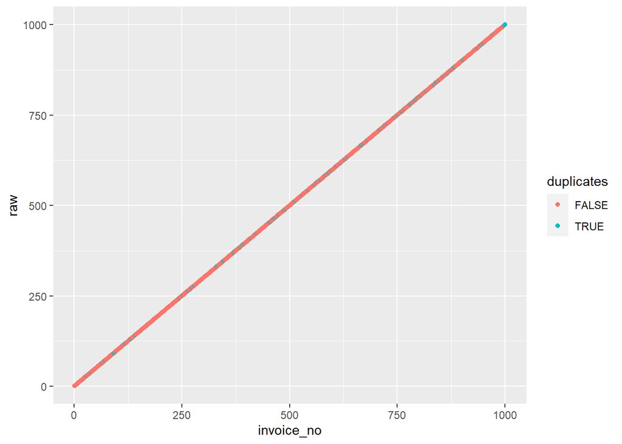

```r
# 寻找重复编号的*可视化*
library(tidyverse)
library(lubridate)
library(kableExtra)
rdate <- function(x, min = paste0(format(Sys.Date(), '%Y'), '-01-01'), max = paste0(format(Sys.Date(), '%Y'), '-12-31'), sort = TRUE) {
  dates <- sample(seq(as.Date(min), as.Date(max), by = "day"), x, replace = TRUE)
  if (sort == TRUE) { sort(dates) } else { dates } }
invoice_no <- date <- 1:1000
journal_ent_no <- cbind.data.frame(invoice_no,date)
date <- rdate(1000)
journal_ent_no$date <- date[order(date)]
journal_ent_no$invoice_no <- seq(1,1000) + rbinom(1000,1,.1)
# 以上代码是用随机抽样方法生成的测试数据
duplicates <- duplicated(journal_ent_no$invoice_no)
# 生成一个逻辑数据，条件是invoice_no是否重复；
raw <- seq(1,1000)
journal_dups <- cbind.data.frame(raw,duplicates)
ggplot(journal_dups, aes(x=invoice_no, y=raw, col=duplicates)) + geom_point()
```

这个图和代码就是看看发票号码有没有重复，重复的发票号码用不同颜色标识出来

我们也可以使用表格，呈现遗漏值和重复值的情况

```r
library(tidyverse)
library(kableExtra)
library(reshape2)
# 只保留duplicates==TRUE的变量（行）;
journal_ent_no[journal_dups$duplicates==TRUE,] %>%
  kable(longtable=T, caption = "Duplicated Invoices") %>%
  kable_styling(bootstrap_options = c("striped", "hover", "condensed"),
                full_width = F, font_size=10,) %>%
  column_spec(1, width = "3em") %>%
  column_spec(2, width = "4em")
```

[output not shown]

但是，通过查看图表中的异常情况的数量，可以直接知道问题的严重程度，如果异常的颜色（如图中使用的浅蓝色）占比很大，则图表中可以看出。

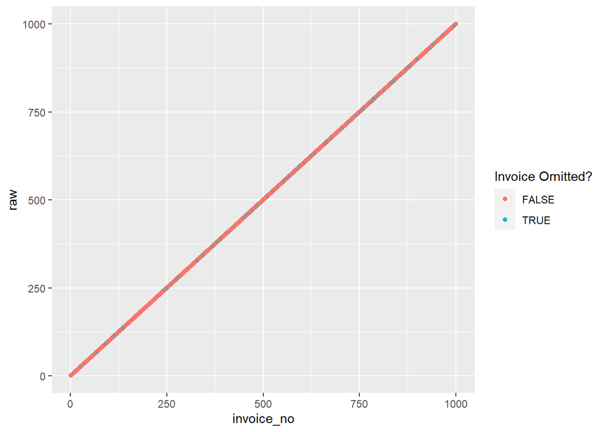

[figure not shown]

```r
# 缺失值的可视化（散点图）
journal_dups$omit <- 0
journal_dups$invoice <- journal_ent_no$invoice_no
journal_dups[journal_dups$raw[!journal_dups$raw %in% journal_ent_no$invoice],"omit"] <- 1
# 原始数据的编号是否包含在自行生成连续编号里面
journal_dups$omit <- as.logical(journal_dups$omit)
ggplot(journal_dups, aes(x=invoice_no, y=raw, col=omit)) + geom_point()+ labs(col = "Invoice Omitted?")
```

## 报告

### 思考题？

大家觉得，我们这个报告跟Word生成的报告有什么优势？在审计报告上，主要体现在那些地方？

```r
RandCall <- function(num){
  i = 0
  re = rep(0,num)
  data<-read.csv('https://toscode.gitee.com/JCHACC/BDA/raw/master/namelist1.csv', sep=',',header=TRUE)
  A<-as.matrix(data[,2:2])
  while(i <= num){
    x = ceiling(runif(1,min = 0, max =length(A)))
    if(xor(is.element(A[x],re),TRUE)){
      re[i] = A[x]
      i = i + 1
    }
  }
  return(re)
}
RandCall(1)
```

```
## [1] "廖聪聪"
```